# Pull Request Flow with usethis

garricakdenbuie.com/blog/pull-request-flow-usethis

Garrick Aden-Buie

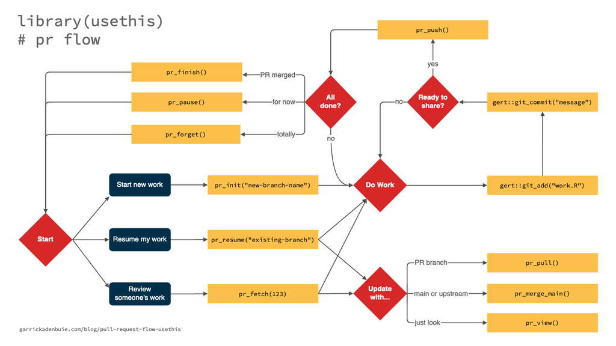

A `usethis` pull request helper function flow diagram. Download the image. ([CC BY](http://creativecommons.org/licenses/by/4.0/))

## The pull request flow

`usethis` has a number of functions that help you move through the pull-request process in a seamless and organized way. This flow chart helps you chose the right function at the right time.

I’ve transcribed the chart above as best I can into a readable list below. The flow chart isn’t a DAG (directed acyclic graph) since work is very much a cyclic activity. In less data science jargon, this means you may have to jump around the list quite a bit.

- **Start**
  - Start new work
    - `usethis::pr_init("new-branch-name")`
    - *Go to* Do Work
  - Resume my work
    - `usethis::pr_resume("existing-branch")`
    - *Go to* Do Work *or* Update with…
  - Review someone’s work
    - `usethis::pr_fetch(123)`
    - *Go to* Do Work *or* Update with…
- **Do Work**
  1. Do work in the branch
     1. Stage files to be committed with `gert::git_add()`
     2. Commit files to the branch with `gert::git_commit()`
  2. Is the work ready to be shared?
     - *If **yes**, go to step 3*
     - *If **no**, return to step 1*
  3. Share local work by pushing to remote branch
     1. `usethis::pr_push()`
     2. Are you done with this branch?
        - *If **yes**, go to* All done?
        - *If **no**, return to step 1*
- **Update with…**
  - the pull request branch
    - `usethis::pr_pull()`
  - the main or upstream branch
    - `usethis::pr_merge_main()`
  - just look at the PR
    - `usethis::pr_view()`
- **All done?**
  - The PR was merged
    - `usethis::pr_finish()`
  - For now, so keep the local branch
    - `usethis::pr_pause()`
  - Totally and the local branch isn’t needed anymore
    - `usethis::pr_forget()`
  - *Return to* Start

## Download the usethis `pr_*()` flow chart

- Small JPG Image (190 KB)
- Medium JPG Image (511 KB)
- Large JPG Image (1.36 MB)
- SVG (40 KB)
- SVG, Editable (40 KB)
- Source File `.drawio` (4 KB)

*Pull Request Flow with usethis* by [Garrick Aden-Buie](https://www.garrickadenbuie.com/blog/pull-request-flow-usethis) is licensed under a [Creative Commons Attribution 4.0 International License](http://creativecommons.org/licenses/by/4.0/).